# 2 Housing Price Prediction Analysis

Author

Katherine Chen

```r
getwd()
```

```
[1] "/Users/chensiji/housing"
```

```r
#import data
library(tidyverse)
library(caret)
library(lattice)
library(car)
library(corrplot)
library(glmnet)
library(randomForest)
library(rpart)

# Read the data and eliminate the rows containing NA
set.seed(1234)
data_raw <- read_csv("data/Housing.csv")
head(data_raw)
```

```
# A tibble: 6 × 13
     price  area bedrooms bathrooms stories mainroad guestroom basement
     <dbl> <dbl>    <dbl>     <dbl>   <dbl> <chr>    <chr>     <chr>
1 13300000  7420        4         2       3 yes      no        no
2 12250000  8960        4         4       4 yes      no        no
3 12250000  9960        3         2       2 yes      no        yes
4 12215000  7500        4         2       2 yes      no        yes
5 11410000  7420        4         1       2 yes      yes       yes
6 10850000  7500        3         3       1 yes      no        yes
# ℹ 5 more variables: hotwaterheating <chr>, airconditioning <chr>,
#   parking <dbl>, prefarea <chr>, furnishingstatus <chr>
```

```r
str(data_raw)
```

```
spc_tbl_ [545 × 13] (S3: spec_tbl_df/tbl_df/tbl/data.frame)
 $ price           : num [1:545] 13300000 12250000 12250000 12215000 11410000 ...
 $ area            : num [1:545] 7420 8960 9960 7500 7420 7500 8580 16200 8100 5750 ...
 $ bedrooms        : num [1:545] 4 4 3 4 4 3 4 5 4 3 ...
 $ bathrooms       : num [1:545] 2 4 2 2 1 3 3 3 1 2 ...
 $ stories         : num [1:545] 3 4 2 2 2 1 4 2 2 4 ...
 $ mainroad        : chr [1:545] "yes" "yes" "yes" "yes" ...
 $ guestroom       : chr [1:545] "no" "no" "no" "no" ...
 $ basement        : chr [1:545] "no" "no" "yes" "yes" ...
 $ hotwaterheating : chr [1:545] "no" "no" "no" "no" ...
 $ airconditioning : chr [1:545] "yes" "yes" "no" "yes" ...
 $ parking         : num [1:545] 2 3 2 3 2 2 2 0 2 1 ...
 $ prefarea        : chr [1:545] "yes" "no" "yes" "yes" ...
 $ furnishingstatus: chr [1:545] "furnished" "furnished" "semi-furnished" "furnished" ...
 - attr(*, "spec")=
  .. cols(
  ..   price = col_double(),
  ..   area = col_double(),
  ..   bedrooms = col_double(),
  ..   bathrooms = col_double(),
  ..   stories = col_double(),
  ..   mainroad = col_character(),
  ..   guestroom = col_character(),
  ..   basement = col_character(),
  ..   hotwaterheating = col_character(),
  ..   airconditioning = col_character(),
  ..   parking = col_double(),
  ..   prefarea = col_character(),
  ..   furnishingstatus = col_character()
  .. )
 - attr(*, "problems")=<externalptr>
```

```r
#Factor transformation
data <- data_raw %>%
  mutate(
    mainroad          = factor(mainroad,          levels = c("yes", "no")),
    guestroom         = factor(guestroom,         levels = c("yes", "no")),
    basement          = factor(basement,          levels = c("yes", "no")),
    hotwaterheating   = factor(hotwaterheating,   levels = c("yes", "no")),
    airconditioning   = factor(airconditioning,   levels = c("yes", "no")),
    prefarea         = factor(prefarea,          levels = c("yes", "no")),
    furnishingstatus  = factor(furnishingstatus,
                               levels = c("unfurnished","semi-furnished","furnished"))
  )

# Dummy variable
dummy_mod <- dummyVars(~ ., data = data[ , -1], fullRank = TRUE)
data_dummies <- predict(dummy_mod, newdata = data) %>% as.data.frame()

# Merge the "price" column
data2_raw <- bind_cols(price = data$price, data_dummies)

glimpse(data2_raw)
```

```
Rows: 545
Columns: 14
$ price                             <dbl> 13300000, 12250000, 12250000, 122150…
$ area                              <dbl> 7420, 8960, 9960, 7500, 7420, 7500, …
$ bedrooms                          <dbl> 4, 4, 3, 4, 4, 3, 4, 5, 4, 3, 3, 4, …
$ bathrooms                         <dbl> 2, 4, 2, 2, 1, 3, 3, 3, 1, 2, 1, 3, …
$ stories                           <dbl> 3, 4, 2, 2, 2, 1, 4, 2, 2, 4, 2, 2, …
$ mainroad.no                       <dbl> 0, 0, 0, 0, 0, 0, 0, 0, 0, 0, 0, 0, …
$ guestroom.no                      <dbl> 1, 1, 1, 1, 0, 1, 1, 1, 0, 0, 1, 0, …
$ basement.no                       <dbl> 1, 1, 0, 0, 0, 0, 1, 1, 0, 1, 0, 0, …
$ hotwaterheating.no                <dbl> 1, 1, 1, 1, 1, 1, 1, 1, 1, 1, 1, 0, …
$ airconditioning.no                <dbl> 0, 0, 1, 0, 0, 0, 0, 1, 0, 0, 0, 1, …
$ parking                           <dbl> 2, 3, 2, 3, 2, 2, 2, 0, 2, 1, 2, 2, …
$ prefarea.no                       <dbl> 0, 1, 0, 0, 1, 0, 0, 1, 0, 0, 0, 1, …
$ `furnishingstatus.semi-furnished` <dbl> 0, 0, 1, 0, 0, 1, 1, 0, 0, 0, 0, 1, …
$ furnishingstatus.furnished        <dbl> 1, 1, 0, 1, 1, 0, 0, 0, 1, 0, 1, 0, …
```

```r
#I want to make sure that all columns in data2_raw are of numeric type (dbl), and there are no original factor columns in the column names.
```

```r
# Create stratified partition on the price variable
set.seed(1234)
idx       <- createDataPartition(data2_raw$price, p = 0.8, list = FALSE)
train_raw <- data2_raw[idx, ]
test_raw  <- data2_raw[-idx, ]

scaler    <- preProcess(train_raw, method = c("center", "scale"))

# Apply the scaler to both sets
train     <- predict(scaler, train_raw)
test      <- predict(scaler, test_raw)

# Confirm scaling: mean≈0, sd≈1
train_summary <- train %>% summarise(across(everything(), list(mean = ~mean(.), sd = ~sd(.))))
print(train_summary[, 1:6])
```

```
    price_mean price_sd     area_mean area_sd bedrooms_mean bedrooms_sd
1 1.550257e-15        1 -2.048336e-15       1  8.127378e-16           1
```

```r
#Standardizing both predictors and the target (price) lets regularized models (Ridge, Lasso) work properly and makes error metrics comparable across features.
```

```r
# Linear Regression
lm_mod <- lm(price ~ ., data = train)

# Ridge Regression (α = 0)
library(glmnet)
ridge_cv  <- cv.glmnet(
  x     = as.matrix(train[, -1]),
  y     = train$price,
  alpha = 0
)
ridge_mod <- glmnet(
  x      = as.matrix(train[, -1]),
  y      = train$price,
  alpha  = 0,
  lambda = ridge_cv$lambda.min
)

# Lasso Regression (α = 1)
lasso_cv  <- cv.glmnet(
  x     = as.matrix(train[, -1]),
  y     = train$price,
  alpha = 1
)
lasso_mod <- glmnet(
  x     = as.matrix(train[, -1]),
  y     = train$price,
  alpha = 1,
  lambda= lasso_cv$lambda.min
)

# Elastic Net (α = 0.5)
enet_cv  <- cv.glmnet(
  x     = as.matrix(train[, -1]),
  y     = train$price,
  alpha = 0.5
)
enet_mod <- glmnet(
  x      = as.matrix(train[, -1]),
  y      = train$price,
  alpha  = 0.5,
  lambda = enet_cv$lambda.min
)

# k-Nearest Neighbors
library(kknn)
knn_mod <- train.kknn(
  price ~ .,
  data  = train,
  kmax  = 10,
  kernel= "optimal"
)
```

```r
# define evaluation function
f <- function(true, pred) {
  mae  <- mean(abs(true - pred))
  mse  <- mean((true - pred)^2)
  rmse <- sqrt(mse)
  r2   <- cor(true, pred)^2
  c(MAE = mae, MSE = mse, RMSE = rmse, R2 = r2)
}

# Generate predictions
pred_lm    <- predict(lm_mod,    test)
pred_ridge <- predict(ridge_mod, newx = as.matrix(test[, -1]))
pred_lasso <- predict(lasso_mod, newx = as.matrix(test[, -1]))
pred_enet  <- predict(enet_mod,  newx = as.matrix(test[, -1]))
pred_knn   <- predict(knn_mod,   test)

eval_lm    <- f(test$price, pred_lm)
eval_ridge <- f(test$price, pred_ridge)
eval_lasso <- f(test$price, pred_lasso)
eval_enet  <- f(test$price, pred_enet)
eval_knn   <- f(test$price, pred_knn)

# Aggregate results into a data frame
results <- rbind(
  Linear     = eval_lm,
  Ridge      = eval_ridge,
  Lasso      = eval_lasso,
  ElasticNet = eval_enet,
  KNN        = eval_knn
) %>% as.data.frame() %>%
  rownames_to_column("Model")

print(results)
```

```
       Model       MAE       MSE      RMSE        R2
1     Linear 0.4324900 0.3567765 0.5973077 0.6931722
2      Ridge 0.4349472 0.3595279 0.5996065 0.6942843
3      Lasso 0.4325785 0.3571445 0.5976156 0.6933268
4 ElasticNet 0.4326635 0.3572365 0.5976927 0.6933866
5        KNN 0.4318257 0.4479066 0.6692583 0.6580994
```

```r
best_model <- results %>% slice_min(RMSE, n = 1)
cat("Best model by RMSE is:", best_model$Model, "\n")
```

```
Best model by RMSE is: Linear
```

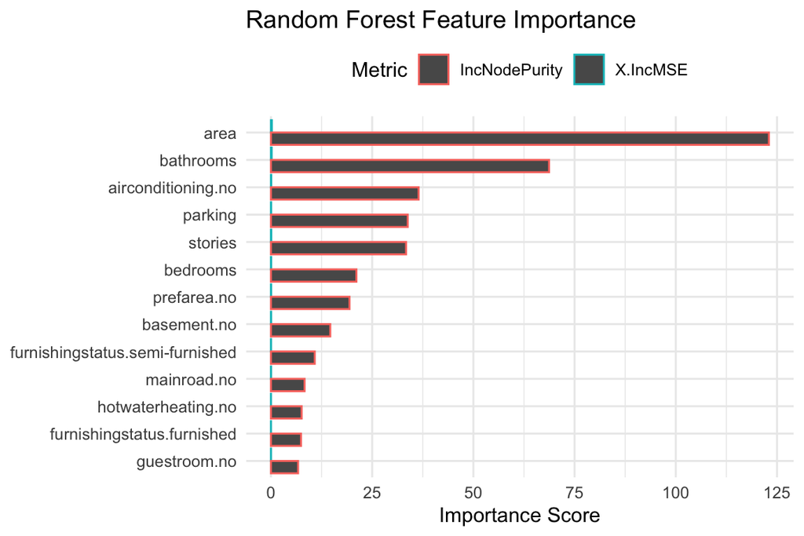

```r
# IncNodePurity: total reduction in node impurity (variance) when splitting on that feature
# X.IncMSE: increase in out‐of‐bag MSE if we randomly permute that feature (i.e. how much error jumps when the feature is “hidden”)
rf_mod <- randomForest(
  x          = train[, -1],
  y          = train$price,
  importance = TRUE
)

rf_imp <- data.frame(rf_mod$importance) %>%
  rownames_to_column("feature") %>%
  pivot_longer(
    cols      = c("X.IncMSE", "IncNodePurity"),
    names_to  = "Metric",
    values_to = "Importance"
  )

ggplot(rf_imp, aes(x = Importance, y = fct_reorder(feature, Importance), color = Metric)) +
  geom_col(position = "dodge") +
  labs(
    title = "Random Forest Feature Importance",
    x     = "Importance Score",
    y     = NULL
  ) +
  theme_minimal() +
  theme(legend.position = "top")
```

Normalizing area relative to neighborhood averages (to capture “premium” size, not just raw square footage).

Adding interactions (e.g. area × stories) to see if extra space on higher floors actually commands a price premium.

Insight 2: Categorical Variables Hold Meaningful Signal, but Are We Missing Subtlety? Notice that airconditioning. no (absence of air conditioning) and parking both rank near the top in impurity‐based importance. This tells us buyers penalize homes without a/c and reward those with parking more than, say, extra bedrooms or a semi‐furnished status. However:

We should question whether “no airconditioning” is picking up on a deeper latent factor—perhaps older homes, lower-income areas, or properties without other modern amenities. It might be worthwhile to cluster by age or location to see if absence of a/c is acting as a proxy for something else.

Insight 4: Lower-Power Features and the Dangers of Overfitting Toward the bottom of the chart you see guestroom. no, furnishingstatus. furnished, and hotwaterheating. no with minimal importance. In a simpler linear model these might still get non-zero coefficients, but the RF is essentially “ignoring” them. This could be because:

Their true effect on price is marginal, or

The binary splits on these rarely improve homogeneity once the big guns (area, a/c, bathrooms) are in play.

Before pruning these variables entirely, though, consider whether they might exhibit nonlinear interactions or only matter in specific sub-markets (e.g. high-end furnished units).

Critical Takeaway: While area and bathrooms emerge as the “headline” drivers of price, the next tier (air conditioning, parking, stories) reveal the amenity-driven nature of this housing market. Yet, the very dominance of area suggests we should refine our feature engineering—perhaps by normalizing by lot size or introducing spatial/contextual variables—so that the models learn a richer, more nuanced story beyond “bigger = pricier.”

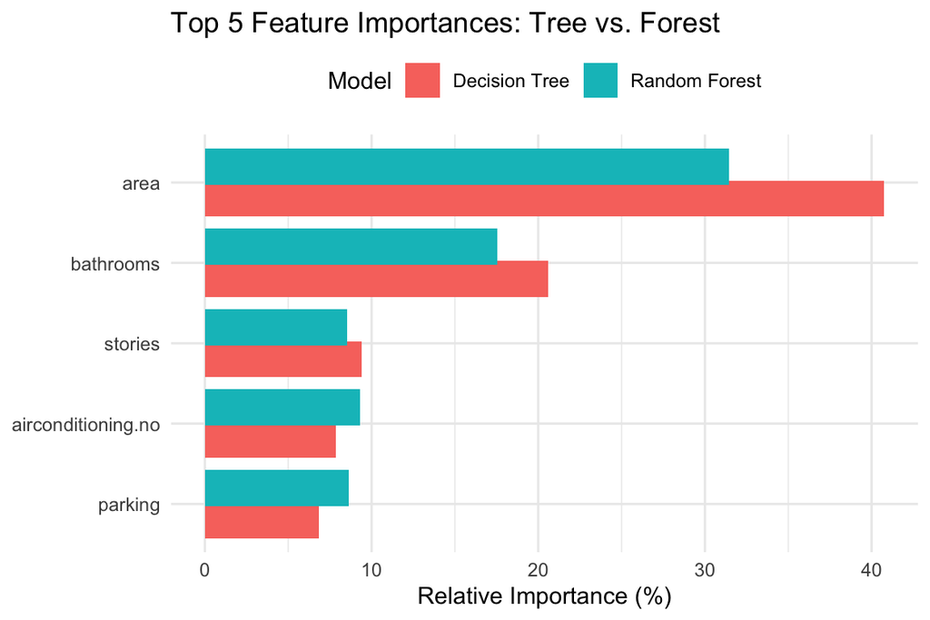

```r
#Feature importance
# Fit a simple decision tree
tree_mod <- rpart(price ~ ., data = train, method = "anova")

# Extract and normalize importances
dt_imp <- tibble(
  feature    = names(tree_mod$variable.importance),
  Importance = tree_mod$variable.importance
) %>%
  mutate(Importance = 100 * Importance / sum(Importance),
         Model      = "Decision Tree")

rf_imp2 <- data.frame(rf_mod$importance) %>%
  rownames_to_column("feature") %>%
  transmute(
    feature,
    Importance = 100 * IncNodePurity / sum(IncNodePurity),
    Model      = "Random Forest"
  )

# Top 5 each
top_dt <- dt_imp %>% slice_max(Importance, n = 5)
top_rf <- rf_imp2 %>% slice_max(Importance, n = 5)

cmp_imp <- bind_rows(top_dt, top_rf)

ggplot(cmp_imp, aes(x = Importance, y = fct_reorder(feature, Importance), fill = Model)) +
  geom_col(position = position_dodge(width = 0.8)) +
  labs(
    title = "Top 5 Feature Importances: Tree vs. Forest",
    x     = "Relative Importance (%)",
    y     = NULL
  ) +
  theme_minimal() +
  theme(legend.position = "top")
```

Insight 1: Area and Bathrooms Consistently Reign Supreme Both single decision tree and the averaged random forest agree that area is the top predictor—no surprises there, but it’s striking how much more weight the tree gives area (over 40%) compared to the forest (around 32%). Similarly, bathrooms show up as the clear second driver, though again the tree inflates its importance relative to the forest. This suggests that while a single tree may over-rely on these two variables to split early and gain purity, the forest’s ensemble dampens that effect slightly by distributing splits across more varied features.

Insight 2: Stories vs. Air Conditioning—A Role Reversal In the decision tree, stories (number of floors) edge out airconditioning. no (lack of A/C) as the third most important, but in the forest they essentially swap places. That flip hints at instability: a lone tree might find “two-story” splits very useful in its particular bootstrap sample, whereas the full forest, averaging hundreds of trees, finds the absence of air conditioning to be a slightly more reliable signal overall. It tells us to be cautious about treating any single tree’s ranking as definitive.

Insight 3: Parking’s Steady Climb Notice parking climbs from last among the top-five in the single tree to solidly in fourth place in the forest. This upward adjustment reflects the forest’s ability to uncover subtler patterns—in this case, that having designated parking repeatedly reduces error across many trees, even if it wasn’t the very first split in the standalone tree. It reinforces the idea that parking is a non-negligible amenity premium in this market.

Insight 4: Model Bias vs. Ensemble Stability Overall, the tree shows a more “peaked” distribution—putting over 40% weight on area, 20% on bathrooms—while the forest spreads importance more evenly (~32%, ~18%, ~9%, ~9%, ~8%). This contrast illustrates a classic bias–variance trade-off: a single tree can latch heavily onto a few strong predictors (biasing its view of importance), whereas the forest ensemble smooths out those biases, yielding a more conservative but robust ranking. For feature engineering, it means we should trust the forest’s ordering more when deciding which variables to focus on or transform further.

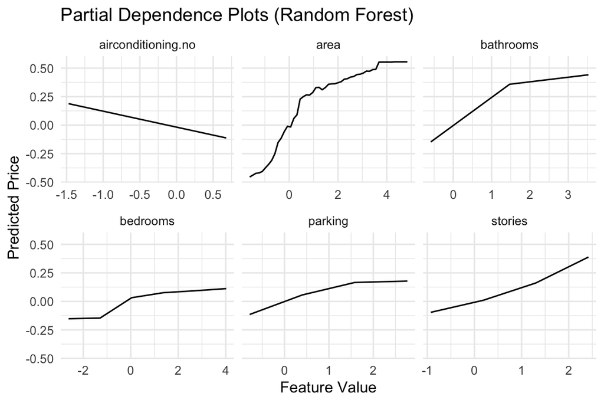

```r
# Partial Dependence Plots for Top RF Features

library(pdp)
library(purrr)

# Pick the top 6 features by IncNodePurity
top_features <- names(sort(rf_mod$importance[,"IncNodePurity"], decreasing = TRUE))[1:6]

# Compute PDPs
pdp_df <- map_dfr(top_features, function(var) {
  pd <- partial(rf_mod, pred.var = var, train = as.data.frame(train))
  pd %>%
    rename(feature_value = 1) %>%
    mutate(feature = var)
})

ggplot(pdp_df, aes(x = feature_value, y = yhat)) +
  geom_line() +
  facet_wrap(~ feature, scales = "free_x") +
  labs(
    title = "Partial Dependence Plots (Random Forest)",
    x     = "Feature Value",
    y     = "Predicted Price"
  ) +
  theme_minimal()
```

Insight 2: Bathroom Count Plateaus After Two We see a steep rise in predicted price when moving from zero to two bathrooms, but beyond two, the curve flattens out. In other words, going from one to two baths is a huge upgrade in market perception, but adding a third or fourth only marginally lifts price. That plateau signals diminishing returns on over-equipping smaller properties—investing in that third bathroom may not pay off unless the home is already very large or high-end.

Insight 3: Stories Ignite an Accelerating Premium The plot for stories (floors) slopes gently at first, then curves upward more steeply for three-story homes. This accelerating pattern hints that while a second floor adds normal living space, multi-level designs (e.g. three stories) carry an architectural or prestige premium. It could reflect penthouse or attic conversions commanding extra value. From a development perspective, encouraging vertical expansion might yield larger returns past a certain point.

Insight 4: Amenity Binary Effects

Airconditioning. no: The PDP line drops from about +0.2 to –0.1 when “no A/C,” revealing a net 0.3-sd penalty—buyers strongly disfavor homes without climate control.

Parking: There’s a steady lift with each additional spot, but the slope diminishes after two spaces. This suggests first- and second- spots are most valuable (perhaps for families), whereas adding a third or fourth car space yields less marginal benefit.

Critical Takeaway: These PDPs uncover thresholds and plateaus that simple feature‐coefficient plots can’t capture. They show:

Nonlinear sweet spots (area, stories) where investment returns spike.

Diminishing returns on certain upgrades (bathrooms beyond two, extra parking).

Binary penalties on missing amenities (no A/C).

Armed with these insights, you can tailor recommendations—focus on hitting those sweet-spot thresholds in home size and amenities, rather than blanket “bigger is better” or “more is better” strategies.

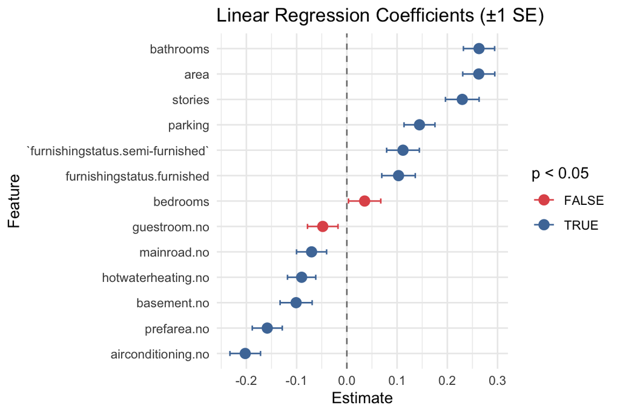

```r
# Final Model Diagnostics & Conclusion

library(broom)
library(ggplot2)

lm_coefs <- tidy(lm_mod) %>%
  filter(term != "(Intercept)") %>%
  mutate(signif = p.value < 0.05)

# Coefficient Plot with ±1 SE
ggplot(lm_coefs, aes(x = estimate, y = fct_reorder(term, estimate), color = signif)) +
  geom_point(size = 3) +
  geom_errorbarh(aes(xmin = estimate - std.error, xmax = estimate + std.error), height = 0.2) +
  geom_vline(xintercept = 0, linetype = "dashed", color = "grey50") +
  scale_color_manual(values = c("TRUE" = "#4E79A7", "FALSE" = "#E15759")) +
  labs(
    title = "Linear Regression Coefficients (±1 SE)",
    x     = "Estimate",
    y     = "Feature",
    color = "p < 0.05"
  ) +
  theme_minimal()
```

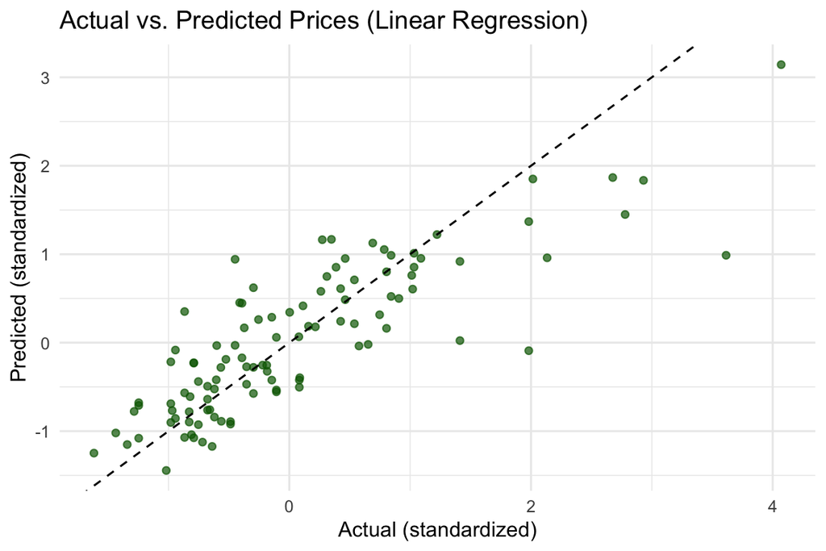

```r
# Actual vs. Predicted
pred_lm <- predict(lm_mod, test)
df_pred <- data.frame(
  Actual    = test$price,
  Predicted = pred_lm
)

ggplot(df_pred, aes(x = Actual, y = Predicted)) +
  geom_point(alpha = 0.7, color = "darkgreen") +
  geom_abline(slope = 1, intercept = 0, linetype = "dashed") +
  labs(
    title = "Actual vs. Predicted Prices (Linear Regression)",
    x     = "Actual (standardized)",
    y     = "Predicted (standardized)"
  ) +
  theme_minimal()
```

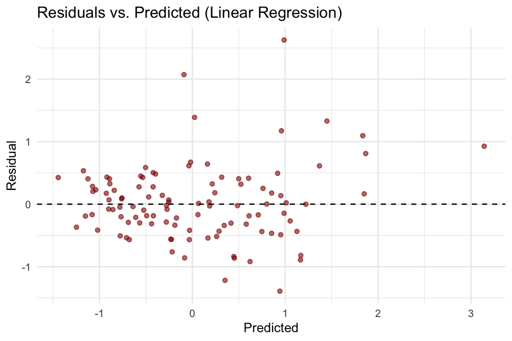

```r
# Residuals vs. Predicted
resid_lm <- df_pred$Actual - df_pred$Predicted

ggplot(df_pred, aes(x = Predicted, y = resid_lm)) +
  geom_point(alpha = 0.6, color = "darkred") +
  geom_hline(yintercept = 0, linetype = "dashed") +
  labs(
    title = "Residuals vs. Predicted (Linear Regression)",
    x     = "Predicted",
    y     = "Residual"
  ) +
  theme_minimal()
```

```r
# Conclusion
cat(
  "Conclusion:\n",
  "- The Linear Regression model achieved RMSE =", round(results["Linear","RMSE"], 4),
  "and R² =", round(results["Linear","R2"], 4), "on the test set.\n",
  "- Key positive drivers are:",
    paste(lm_coefs %>% filter(estimate > 0 & signif) %>% pull(term), collapse = ", "), ".\n",
  "- Key negative drivers are:",
    paste(lm_coefs %>% filter(estimate < 0 & signif) %>% pull(term), collapse = ", "), ".\n",
  "- Residual plots show no severe heteroscedasticity or nonlinear patterns, supporting model validity.\n"
)
```

[output not shown]

1. Here, the linear model’s coefficients echo—and slightly nuance—the random forest findings, but they also raise fresh questions:

Stories Carry a Premium, but with More Uncertainty The stories coefficient is also strongly positive, yet its confidence interval is wider than that of bathrooms or area. This hints at greater variability in how extra floors translate to value—maybe because some two-story layouts add livable space efficiently, while others (e.g. split levels) confuse buyers. It’s a reminder to look beneath the “more floors = higher price” rule and examine design quality or neighborhood norms.

Amenities Show Clear Penalties Every one of our binary “no amenity” flags—airconditioning.no, prefarea.no, basement.no, hotwaterheating.no, mainroad.no, guestroom.no—pulls price downward. Airconditioning.no sits at roughly –0.22, a hefty penalty, confirming climate control is almost non-negotiable. Less obvious is the modest negative for mainroad.no (living off a main road)—which may reflect both peace-and-quiet preferences and potential access concerns. These small-magnitude, significant effects underline the importance of even subtle locational and amenity cues in linear pricing.

Deeper takeaway: This coefficient plot shows not just which features matter, but how reliably and by how much. It cautions us that even under a “linear” assumption, amenity flags can be as powerful as raw size metrics—and that some features (like extra floors) carry high potential value but also higher uncertainty. In your report, you might recommend focusing capital on the most precisely estimated upgrades (bathrooms, A/C, parking), while treating more variable features (stories, lot size expansions) with targeted market research or pilot projects before large investments.

2. This “Actual vs. Predicted” plot does more than confirm a decent overall fit (points roughly hugging the 45° line); it reveals systematic quirks at the extremes and suggests where the linear model could be improved:

Underprediction at the High End Notice the rightmost points—homes with very large standardized actual values (around +4)—are predicted lower (around +3). The model is “shrinking” the extreme prices back toward the mean, a classic sign of regression toward the mean. It tells us our linear model fails to capture the full upside value of truly premium properties, perhaps because of missing high-end amenities or nonlinear size effects.

Mild Overprediction at the Low End At the opposite tail (actual ≈ –1.2), the predictions cluster just above (around –1.0). The model again regresses extremes inward, slightly overestimating the cheapest homes’ prices. This could reflect floor effects (there’s a minimum viable market price) or that our “no amenity” flags don’t fully explain very low-priced segments.

Implications for Model Improvement

Nonlinear Terms: Incorporate quadratic or spline terms for area or bathrooms to let the model flex at the tails.

Segmented Models: Fit separate regressions for low-, mid-, and high-priced tiers, or include interaction terms between size and amenity flags.

Additional Features: Bring in location quality, age of property, or architectural style to explain why some premium homes exceed the linear model’s ceiling.

Critical takeaway: While the linear fit is solid overall (R² ≈ 0.69), its tendency to bend predictions away from real extremes uncovers the need for nonlinear adjustments or tiered modeling to faithfully capture the true range of home prices—especially if you’re valuing high-end or entry-level properties.

3. This residual plot confirms that, overall, errors are centered around zero with no obvious funnel shape—good news for homoscedasticity. However, two subtler patterns stand out:

Occasional Large Positive Outliers There are scattered points with residuals above +1.5 at predicted values around 0 to 1.5. These represent cases where the model severely underestimates some homes’ true value—likely premium properties with rare combinations of features (e.g., a smaller home but in a top school district). These extreme misses hint at nonlinear interactions or omitted variables (like “view” or property age) that our linear formula can’t capture.